# Explotary Analysis

R Coders

December 16, 2018

```r
#required packages
install.packages("tidyverse", repos = "https://cran.r-project.org")
install.packages("dplyr", repos = "https://cran.r-project.org")
install.packages("readxl", repos = "http://cran.us.r-project.org")
```

```r
install.packages("ggplot2", repos = "http://cran.us.r-project.org")
install.packages("plotly", repos = "http://cran.us.r-project.org")
install.packages("gapminder", repos = "http://cran.us.r-project.org")
#install.packages("xlsx", repos = "http://cran.us.r-project.org")
install.packages("sqldf", repos = "http://cran.us.r-project.org")
library("tidyverse")
library("readxl")
library("ggplot2")
library("plotly")
library("gapminder")
#library("xlsx")
library("sqldf")
library("dplyr")
```

#### Download RDS Data from Github Page

Download export, import, USD Rate and Inflation rds files and put them in temp files and read them.  
And remove the temp files after reading.

```r
tmp<-tempfile(fileext=".rds")
download.file("https://github.com/MEF-BDA503/gpj18-r_coders/blob/master/Data_Sources_Rds/imp_data_final.rds?raw=true?raw=true",destfile=tmp,mode = 'wb')
imp_data_final<-read_rds(tmp)
file.remove(tmp)
```

```
## [1] TRUE
```

```r
tmp<-tempfile(fileext=".rds")
download.file("https://github.com/MEF-BDA503/gpj18-r_coders/blob/master/Data_Sources_Rds/exp_data_final.rds?raw=true?raw=true",destfile=tmp,mode = 'wb')
exp_data_final<-read_rds(tmp)
file.remove(tmp)
```

```
## [1] TRUE
```

```r
tmp<-tempfile(fileext=".rds")
download.file("https://github.com/MEF-BDA503/gpj18-r_coders/blob/master/Data_Sources_Rds/imp_data.rds?raw=true?raw=true",destfile=tmp,mode = 'wb')
imp_data<-read_rds(tmp)
file.remove(tmp)
```

```
## [1] TRUE
```

```r
tmp<-tempfile(fileext=".rds")
download.file("https://github.com/MEF-BDA503/gpj18-r_coders/blob/master/Data_Sources_Rds/exp_data.rds?raw=true?raw=true",destfile=tmp,mode = 'wb')
exp_data<-read_rds(tmp)
file.remove(tmp)
```

```
## [1] TRUE
```

```r
tmp<-tempfile(fileext=".rds")
download.file("https://github.com/MEF-BDA503/gpj18-r_coders/blob/master/Data_Sources_Rds/Producer_Inflation.rds?raw=true?raw=true",destfile=tmp,mode = 'wb')
producer_inf<-read_rds(tmp)
file.remove(tmp)
```

```
## [1] TRUE
```

```r
# Create a temporary file
tmp=tempfile(fileext=".xls")
# Download file from repository to the temp file
download.file("https://github.com/MEF-BDA503/gpj18-r_coders/blob/master/Data_Sources_Excel/export_import_sectors.xls?raw=true",destfile=tmp,mode='wb')
# Read that excel file.
sectors <- read_excel(tmp)
```

```
## readxl works best with a newer version of the tibble package.
## You currently have tibble v1.4.2.
## Falling back to column name repair from tibble <= v1.4.2.
## Message displays once per session.
```

```r
# Remove the temp file
file.remove(tmp)
```

```
## [1] TRUE
```

```r
tmp<-tempfile(fileext=".rds")
download.file("https://github.com/MEF-BDA503/gpj18-r_coders/blob/master/Data_Sources_Rds/US_Dollar_Montly_Rate.rds?raw=true?raw=true",destfile=tmp,mode = 'wb')
usd_rate<-read_rds(tmp)
file.remove(tmp)
```

```
## [1] TRUE
```

Format Data

```r
names(exp_data_final)[names(exp_data_final) == 'Date'] <- 'Export_Date'
names(exp_data)[names(exp_data) == 'Date'] <- 'Export_Date'
names(imp_data_final)[names(imp_data_final) == 'Date'] <- 'Import_Date'
names(imp_data_final)[names(imp_data_final) == 'Export_Total_Amount'] <- 'Import_Total_Amount' #fix
names(imp_data)[names(imp_data) == 'Date'] <- 'Import_Date'


library("dplyr")
exp_data <- inner_join(exp_data,sectors, by=c("Sector_Type_Code"="Sub_Sector_Type_Code"))

imp_data <- inner_join(imp_data,sectors, by=c("Sector_Type_Code"="Sub_Sector_Type_Code"))

exp_data$Export_Year<-as.numeric(format(exp_data$Export_Date,"%Y"))
exp_data$Export_Year_Month<-format(exp_data$Export_Date,"%Y-%m")
exp_data_final$Export_Year<-as.numeric(format(exp_data_final$Export_Date,"%Y"))
exp_data_final$Export_Year_Month<-format(exp_data_final$Export_Date,"%Y-%m")

imp_data$Import_Year<-as.numeric(format(imp_data$Import_Date,"%Y"))
imp_data$Import_Year_Month<-format(imp_data$Import_Date,"%Y-%m")
imp_data_final$Import_Year<-as.numeric(format(imp_data_final$Import_Date,"%Y"))
imp_data_final$Import_Year_Month<-format(imp_data_final$Import_Date,"%Y-%m")

imp_data<- imp_data %>%
  select (Import_Date,Sector_Type_Code,Sector_Type_Code.y,Main_Sector_Flag,Sector_Name_Eng,Amount,Import_Year,Import_Year_Month)


exp_data<- exp_data %>%
  select (Export_Date,Sector_Type_Code,Sector_Type_Code.y,Main_Sector_Flag,Sector_Name_Eng, Amount,Export_Year,Export_Year_Month)



colnames(imp_data)[colnames(imp_data) == 'Amount'] <- 'Import_Amount'
colnames(exp_data)[colnames(exp_data) == 'Amount'] <- 'Export_Amount'
colnames(imp_data)[colnames(imp_data) == 'Sector_Type_Code'] <- 'Sub_Sector_Type_Code'
colnames(exp_data)[colnames(exp_data) == 'Sector_Type_Code'] <- 'Sub_Sector_Type_Code'
colnames(imp_data)[colnames(imp_data) == 'Sector_Type_Code.y'] <- 'Sector_Type_Code'
colnames(exp_data)[colnames(exp_data) == 'Sector_Type_Code.y'] <- 'Sector_Type_Code'
imp_data$Import_Amount[is.na(imp_data$Import_Amount)] <- 0
imp_data_final$Import_Total_Amount[is.na(imp_data_final$Import_Total_Amount)] <- 0
exp_data$Export_Amount[is.na(exp_data$Export_Amount)] <- 0
exp_data_final$Export_Total_Amount[is.na(exp_data_final$Export_Total_Amount)] <- 0


exp_data_final <- exp_data_final %>%
  filter(Export_Date<'2018-11-01')

exp_data <- exp_data %>%
  filter(Export_Date<'2018-11-01')

imp_data_final <- imp_data_final %>%
  filter(Import_Date<'2018-11-01')

imp_data <- imp_data %>%
  filter(Import_Date<'2018-11-01')

saveRDS(imp_data,file="imp_data_v2.rds")
saveRDS(imp_data_final,file="imp_data_final_v2.rds")
saveRDS(exp_data,file="exp_data_v2.rds")
saveRDS(exp_data_final,file="exp_data_final_v2.rds")
```

Review Import Data Structure

```r
str(imp_data)
```

```
## Classes 'tbl_df', 'tbl' and 'data.frame':    4236 obs. of  8 variables:
##  $ Import_Date         : Date, format: "2018-01-01" "2018-01-01" ...
##  $ Sub_Sector_Type_Code: chr  "A" "01" "02" "B" ...
##  $ Sector_Type_Code    : chr  "A" "A" "A" "B" ...
##  $ Main_Sector_Flag    : num  1 0 0 1 0 1 0 0 0 0 ...
##  $ Sector_Name_Eng     : chr  "Agriculture and forestry" "Agriculture, hunting and related service activities" "Forestry, logging and related service activities" "Fishing" ...
##  $ Import_Amount       : num  975964 966980 8985 5223 5223 ...
##  $ Import_Year         : num  2018 2018 2018 2018 2018 ...
##  $ Import_Year_Month   : chr  "2018-01" "2018-01" "2018-01" "2018-01" ...
```

```r
str(imp_data_final)
```

```
## Classes 'tbl_df', 'tbl' and 'data.frame':    94 obs. of  7 variables:
##  $ Import_Date                        : Date, format: "2010-07-01" "2010-08-01" ...
##  $ Import_Total_Amount                : num  26002098 24474224 24503919 26842444 26584903 ...
##  $ Consumer_Price_Index_Yearly_Change : num  7.58 8.33 9.24 8.62 7.29 6.4 4.9 4.16 3.99 4.26 ...
##  $ Consumer_Price_Index_Monthly_Change: num  -0.48 0.4 1.23 1.83 0.03 -0.3 0.41 0.73 0.42 0.87 ...
##  $ USD_Rate                           : num  1.53 1.5 1.49 1.42 1.43 ...
##  $ Import_Year                        : num  2010 2010 2010 2010 2010 ...
##  $ Import_Year_Month                  : chr  "2010-07" "2010-08" "2010-09" "2010-10" ...
```

Review Export Data Structure

```r
str(exp_data)
```

```
## Classes 'tbl_df', 'tbl' and 'data.frame':    4452 obs. of  8 variables:
##  $ Export_Date         : Date, format: "2018-01-01" "2018-01-01" ...
##  $ Sub_Sector_Type_Code: chr  "A" "01" "02" "B" ...
##  $ Sector_Type_Code    : chr  "A" "A" "A" "B" ...
##  $ Main_Sector_Flag    : num  1 0 0 1 0 1 0 0 0 0 ...
##  $ Sector_Name_Eng     : chr  "Agriculture and forestry" "Agriculture, hunting and related service activities" "Forestry, logging and related service activities" "Fishing" ...
##  $ Export_Amount       : num  529803 527251 2551 49826 49826 ...
##  $ Export_Year         : num  2018 2018 2018 2018 2018 ...
##  $ Export_Year_Month   : chr  "2018-01" "2018-01" "2018-01" "2018-01" ...
```

```r
str(exp_data_final)
```

```
## Classes 'tbl_df', 'tbl' and 'data.frame':    94 obs. of  7 variables:
##  $ Export_Date                        : Date, format: "2010-07-01" "2010-08-01" ...
##  $ Export_Total_Amount                : num  19129365 17046904 17818461 21927173 18764739 ...
##  $ Consumer_Price_Index_Yearly_Change : num  7.58 8.33 9.24 8.62 7.29 6.4 4.9 4.16 3.99 4.26 ...
##  $ Consumer_Price_Index_Monthly_Change: num  -0.48 0.4 1.23 1.83 0.03 -0.3 0.41 0.73 0.42 0.87 ...
##  $ USD_Rate                           : num  1.53 1.5 1.49 1.42 1.43 ...
##  $ Export_Year                        : num  2010 2010 2010 2010 2010 ...
##  $ Export_Year_Month                  : chr  "2010-07" "2010-08" "2010-09" "2010-10" ...
```

Prepare Data for Import&Export Line Graph

```r
imp_and_exp_data <- inner_join(exp_data, imp_data, by=c("Export_Date" = "Import_Date","Sub_Sector_Type_Code"="Sub_Sector_Type_Code"))

imp_and_exp_data_bymonth <- aggregate(cbind(Import_Amount, Export_Amount) ~ Export_Date, data = imp_and_exp_data, sum)
imp_and_exp_data_bymonth <- gather(imp_and_exp_data_bymonth,
                               value = "value",
                               key = "type",
                               Export_Amount, Import_Amount)

#Rename column names
colnames(imp_and_exp_data_bymonth) <- c("Date","Type","Amount")

#Remove Empty Dates
imp_and_exp_data_bymonth <- imp_and_exp_data_bymonth %>%
  filter(Date<'2018-11-01')
```

## Export and Import Amount

The graph shows the year-based comparison of export and import amount data. A very long period of increases and decreases are moving synchronously. In April 2018, the import amount Line has a major decline, while export amount Line has a major increase.

```r
 p<-ggplot(imp_and_exp_data_bymonth,
        aes(x=Date,
            y=Amount/1000,
            color=Type)) +
   geom_line()+
   scale_size_area("Nitrogen") +
   xlab("Import/Export Date") +
   ylab("Amount  (Million $)") +
   ggtitle("Import & Export Amount")
 style(p, text = row.names(imp_and_exp_data_bymonth))
```

[interactive chart not shown]

## Export Amount Based on Consumer Price Index and USD Rate

The graph shows export amount based on consumer price index and USD rate on monthly basis. Each year is indicated in different colors and every point shows monthly variables values.

```r
p <- exp_data_final %>%
  ggplot(aes(USD_Rate, Export_Total_Amount, size = Consumer_Price_Index_Yearly_Change, color=Export_Year)) +
  geom_point() +
  scale_x_log10() +
  theme_bw()+
  scale_size_area("Nitrogen") +
  xlab("USD Rate") +
  ylab("Export Amount(1000$)") +
  ggtitle("Export Amounts and Consumer Price Index")

ggplotly(p)
```

[interactive chart not shown]

```r
p <-
  plot_ly(data = exp_data_final, x = exp_data_final$Consumer_Price_Index_Yearly_Change, y = exp_data_final$Export_Total_Amount, size = exp_data_final$Consumer_Price_Index_Yearly_Change, color=exp_data_final$Export_Year,text = ~paste('Export Date:', exp_data_final$Export_Date, '<br>USD Rate:', exp_data_final$USD_Rate,
                                                                                                                                                                                                                                         '<br>Consumer Price Index Yearly Change:', exp_data_final$Consumer_Price_Index_Yearly_Change,
                                                                                                                                                                                                                                         '<br>Consumer Price Index Monthly Change:', exp_data_final$Consumer_Price_Index_Monthly_Change,
                                                                                                                                                                                                                                         '<br>Export Amount:', exp_data_final$Export_Total_Amount))  %>%
  layout(title = 'Export Amounts and  Consumer Price Index',
         xaxis = list(title =  'Consumer Price Index',
                      gridcolor = 'rgb(255, 255, 255)',
                      type = 'log',
                      zerolinewidth = 1,
                      ticklen = 5,
                      gridwidth = 2),
         yaxis = list(title ='Export Amount',
                      gridcolor = 'rgb(255, 255, 255)',
                      zerolinewidth = 1,
                      ticklen = 5,
                      gridwith = 2),
         paper_bgcolor = 'rgb(243, 243, 243)',
         plot_bgcolor = 'rgb(243, 243, 243)')

ggplotly(p)
```

[interactive chart not shown]

## Import Amount Based on Consumer Price Index and USD Rate

The graph shows import amount based on consumer price index and USD rate on monthly basis. Each year is indicated in different colors and every point shows monthly variables values.

```r
p <-
  plot_ly(data = imp_data_final, x = imp_data_final$Consumer_Price_Index_Yearly_Change, y = imp_data_final$Import_Total_Amount, size = imp_data_final$Consumer_Price_Index_Yearly_Change, color=imp_data_final$Import_Year,text = ~paste('Import Date:', imp_data_final$Import_Date, '<br>USD Rate:', imp_data_final$USD_Rate,
'<br>Consumer Price Index Yearly Change:', imp_data_final$Consumer_Price_Index_Yearly_Change,
'<br>Consumer Price Index Monthly Change:', imp_data_final$Consumer_Price_Index_Monthly_Change,
'<br>Import Amount:', imp_data_final$Import_Total_Amount))  %>%
  layout(title = 'Import Amounts and Consumer Price Index',
         xaxis = list(title =  'Consumer Price Index',
                      gridcolor = 'rgb(255, 255, 255)',
                      type = 'log',
                      zerolinewidth = 1,
                      ticklen = 5,
                      gridwidth = 2),
         yaxis = list(title ='Import Amount',
                      gridcolor = 'rgb(255, 255, 255)',
                      zerolinewidth = 1,
                      ticklen = 5,
                      gridwith = 2),
         paper_bgcolor = 'rgb(243, 243, 243)',
         plot_bgcolor = 'rgb(243, 243, 243)')

ggplotly(p)
```

[interactive chart not shown]

```r
top_import_by_sector <-
  imp_data %>%
  filter(Main_Sector_Flag==1)%>% #& Import_Year==2018) %>%
  group_by(Import_Year,Sector_Type_Code,Sector_Name_Eng) %>%
  summarise(Import_Total_Amount=sum(Import_Amount))%>%
  arrange(desc(Import_Total_Amount))



top_export_by_sector <-
  exp_data %>%
  filter(Main_Sector_Flag==1)%>% #& Export_Year==2018) %>%
  group_by(Export_Year,Sector_Type_Code,Sector_Name_Eng) %>%
  summarise(Export_Total_Amount=sum(Export_Amount))%>%
  arrange(desc(Export_Total_Amount))

trade_deficit_by_sectors<-sqldf('select Export_Year as Year, a.Sector_Type_Code,
a.Sector_Name_Eng, Export_Total_Amount, Import_Total_Amount,
(Import_Total_Amount - Export_Total_Amount) as Trade_Deficit_Amount
    from top_export_by_sector a left join top_import_by_sector b
      on Export_Year = Import_Year
      and a.Sector_Type_Code = b.Sector_Type_Code')

trade_deficit_by_sectors$Import_Total_Amount[is.na(trade_deficit_by_sectors$Import_Total_Amount)] <- 0
trade_deficit_by_sectors$Trade_Deficit_Amount[is.na(trade_deficit_by_sectors$Trade_Deficit_Amount)] <- 0
```

#### Top sectors for Export

```r
head(top_export_by_sector)
```

```
## # A tibble: 6 x 4
## # Groups:   Export_Year, Sector_Type_Code [6]
##   Export_Year Sector_Type_Code Sector_Name_Eng Export_Total_Amount
##         <dbl> <chr>            <chr>                         <dbl>
## 1        2017 D                Manufacturing            147138203.
## 2        2014 D                Manufacturing            147059418.
## 3        2012 D                Manufacturing            143193911.
## 4        2013 D                Manufacturing            141358199.
## 5        2015 D                Manufacturing            134389890.
## 6        2016 D                Manufacturing            133595801.
```

#### Top sectors for Import

```r
head(top_import_by_sector)
```

```
## # A tibble: 6 x 4
## # Groups:   Import_Year, Sector_Type_Code [6]
##   Import_Year Sector_Type_Code Sector_Name_Eng Import_Total_Amount
##         <dbl> <chr>            <chr>                         <dbl>
## 1        2013 D                Manufacturing            196822807.
## 2        2017 D                Manufacturing            190748102.
## 3        2014 D                Manufacturing            187742215.
## 4        2011 D                Manufacturing            183930287.
## 5        2012 D                Manufacturing            176235027.
## 6        2016 D                Manufacturing            167243395.
```

## Yearly Trade Deficit Amount

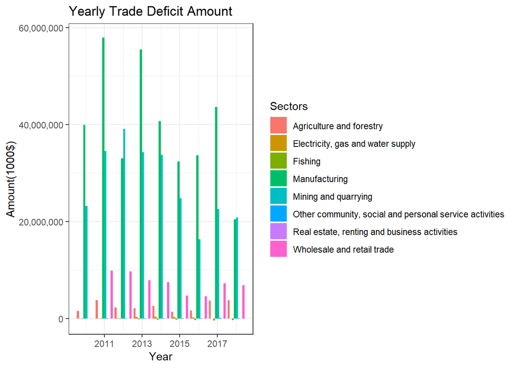

```r
trade_deficit_by_sectors %>%
  #filter(Main_Sector_Flag==1)%>%
  group_by(Year,Sector_Name_Eng) %>%
  summarise(Yearly_Total_Trade_Deficit_Amount=sum(Trade_Deficit_Amount))%>%
  ggplot(data = ., aes(x = Year, y = Yearly_Total_Trade_Deficit_Amount,
                       fill = Sector_Name_Eng)) + geom_bar(stat = "identity", position=position_dodge()) + aes(x = Year, y =   Yearly_Total_Trade_Deficit_Amount) + labs(x = "", y = "", title = "Yearly Trade Deficit Amount") + theme_bw() +  scale_y_continuous(labels = scales::comma) +   guides(fill=guide_legend(title="Sectors"))+
  xlab("Year") +
  ylab("Amount(1000$)")
```

### Preparation Data for Yearly Average Export Amount and Other Factors

```r
library("dplyr")
exp_data_total_amount_by_year <-
  exp_data %>%
  group_by(Export_Date,Export_Year) %>%
  summarise(Yearly_Export_Total_Amount=sum(Export_Amount))

exp_data_amount_and_others <- inner_join(exp_data_final,exp_data_total_amount_by_year, by=c("Export_Date" = "Export_Date"))
#str(exp_data_amount_and_others) for test

exp_data_amount_and_others$Export_Year.x <- as.numeric(as.character(exp_data_amount_and_others$Export_Year.x))
#str(exp_data_amount_and_others) for test

colnames(exp_data_amount_and_others)[colnames(exp_data_amount_and_others) == 'Export_Year.x'] <- 'Export_Year'

  exp_data_amount_and_others_yearly <-
  exp_data_amount_and_others %>%
  group_by(Export_Year) %>%
  summarise(Yearly_Avg_Export_Amount=mean(Yearly_Export_Total_Amount),
            Yearly_Avg_Consumer_Price_Index_Yearly_Change = mean(Consumer_Price_Index_Yearly_Change),
            Yearly_Avg_Consumer_Price_Index_Monthly_Change = mean(Consumer_Price_Index_Monthly_Change),
            Yearly_Avg_USD_Rate = mean(USD_Rate))

head(exp_data_amount_and_others)
```

```
## # A tibble: 6 x 9
##   Export_Date Export_Total_Am~ Consumer_Price_~ Consumer_Price_~ USD_Rate
##   <date>                 <dbl>            <dbl>            <dbl>    <dbl>
## 1 2010-07-01         19129365.             7.58            -0.48     1.53
## 2 2010-08-01         17046904.             8.33             0.4      1.50
## 3 2010-09-01         17818461.             9.24             1.23     1.49
## 4 2010-10-01         21927173.             8.62             1.83     1.42
## 5 2010-11-01         18764739.             7.29             0.03     1.43
## 6 2010-12-01         23645103.             6.4             -0.3      1.51
## # ... with 4 more variables: Export_Year <dbl>, Export_Year_Month <chr>,
## #   Export_Year.y <dbl>, Yearly_Export_Total_Amount <dbl>
```

## Yearly Average Export Amount and Other Factors

Yearly average export amount and other factors show the inflation rate of the points in the chart. At every point can be seen yearly average USD rate, yearly average export amount, yearly average consumer price index yearly change.

```r
#Export_Yearly_Avg_Values
library("ggplot2")
library("plotly")
  p <- exp_data_amount_and_others_yearly %>%
    ggplot(aes(Yearly_Avg_USD_Rate, Yearly_Avg_Export_Amount, size = Yearly_Avg_Consumer_Price_Index_Yearly_Change, color=Export_Year)) +
    geom_point() +
    scale_x_log10() +
    theme_bw()+
    xlab("USD Rate") +
    ylab("Export Amount(1000$)") +
    ggtitle("Yearly Average Export Amount and Other Factors")

  ggplotly(p)
```

[interactive chart not shown]

#### Minimum, Maximum, Average and Total Export Amounts by Sectors and Years

```r
exp_min_max_mean_by_sectors<- exp_data %>%
  filter(Main_Sector_Flag==1)%>%
  group_by(Export_Year,Sector_Name_Eng) %>%
  summarise_each(funs(min(.,na.rm=TRUE), round(mean(.,na.rm=TRUE),digits = 3), max(.,na.rm=TRUE),sum(.,na.rm=TRUE)),Export_Amount)
```

```
## `summarise_each()` is deprecated.
## Use `summarise_all()`, `summarise_at()` or `summarise_if()` instead.
## To map `funs` over a selection of variables, use `summarise_at()`
```

```r
head(exp_min_max_mean_by_sectors)
```

```
## # A tibble: 6 x 6
## # Groups:   Export_Year [1]
##   Export_Year Sector_Name_Eng                    min  round     max     sum
##         <dbl> <chr>                            <dbl>  <dbl>   <dbl>   <dbl>
## 1        2010 Agriculture and forestry        2.87e5 4.11e5  5.70e5  4.93e6
## 2        2010 Electricity, gas and water s~   7.61e3 1.51e4  2.63e4  1.81e5
## 3        2010 Fishing                         8.28e3 1.30e4  2.57e4  1.56e5
## 4        2010 Manufacturing                   7.18e6 8.79e6  1.09e7  1.05e8
## 5        2010 Mining and quarrying            1.48e5 2.24e5  2.60e5  2.69e6
## 6        2010 Other community, social and ~   4.18e1 3.01e2  5.89e2  3.62e3
```

## Export Sector Share

The graph shows the sector shares in the total export amount. Only one sector is above the sector average export amount. Manufacturing export amount is higher than the total of the other sector import amounts.

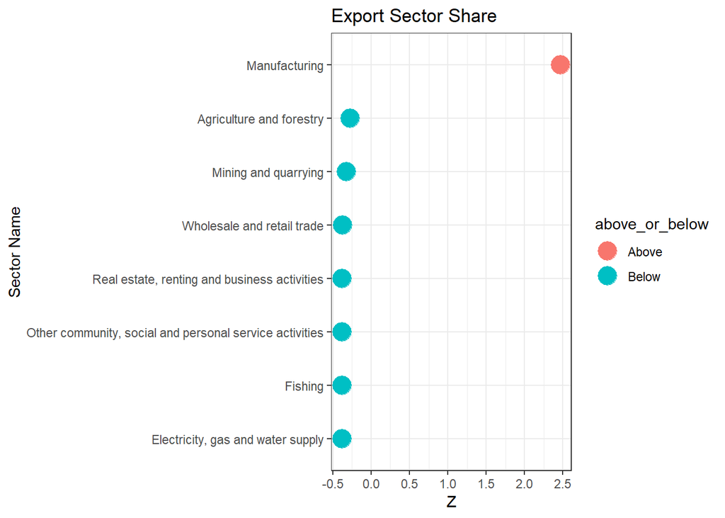

```r
exp_share_sectors <-
  exp_data  %>%
  filter(Main_Sector_Flag==1 & Export_Date<'2018-11-01')%>%
  group_by(Sector_Name_Eng) %>%
  summarize(Export_Amount_Share=sum(Export_Amount)) %>%
  mutate (Export_Amount_Share=round((Export_Amount_Share/sum(Export_Amount_Share)),4))


exp_share_sectors$share_z <- round((exp_share_sectors$Export_Amount_Share - mean(exp_share_sectors$Export_Amount_Share))/sd(exp_share_sectors$Export_Amount_Share), 2)

exp_share_sectors$above_or_below <- ifelse(exp_share_sectors$share_z < 0, "Below", "Above")
exp_share_sectors <- exp_share_sectors[order(exp_share_sectors$share_z), ]
exp_share_sectors$Sector_Name_Eng <- factor(exp_share_sectors$Sector_Name_Eng, levels = exp_share_sectors$Sector_Name_Eng)


theme_set(theme_bw())

ggplot(exp_share_sectors, aes(x= share_z   , y=  Sector_Name_Eng, label=share_z)) +
  xlab("Z") +
  ylab("Sector Name") +
  ggtitle("Export Sector Share")+
  geom_point(stat='identity', aes(col=above_or_below), size=6) #+
```

## Import Sector Share

The graph shows the sector shares in the total import amount. Only two sector is above the sector average import amount because of that manufacturing is extremely higher than other sectors. Mining is also important but manufacturing import amount is higher than the total of the other sector import amounts.

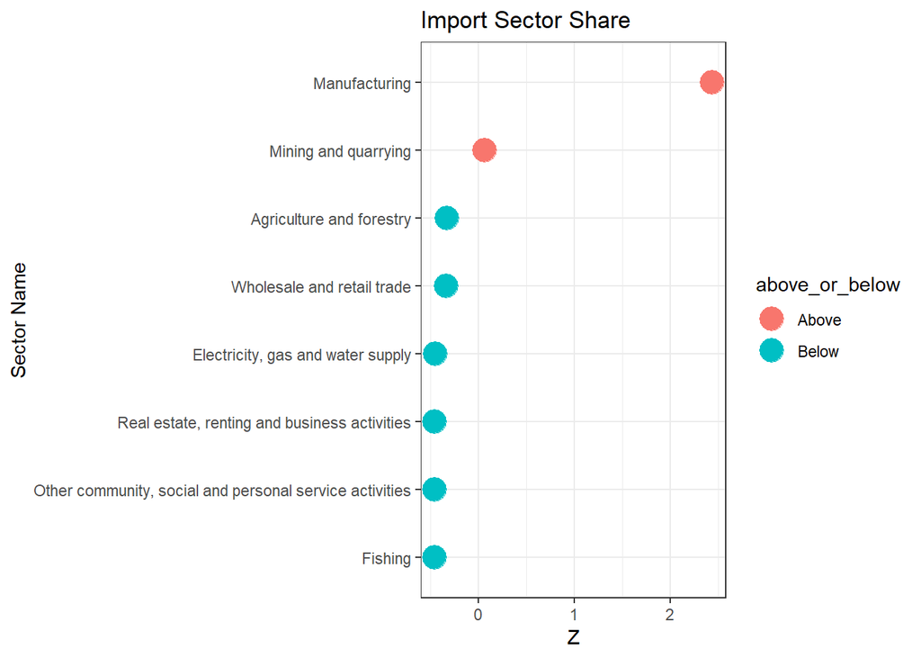

```r
imp_share_sectors <-
  imp_data  %>%
  filter(Main_Sector_Flag==1 & Import_Date<'2018-11-01')%>%
  group_by(Sector_Name_Eng) %>%
  summarize(Import_Amount_Share=sum(Import_Amount)) %>%
  mutate (Import_Amount_Share=round((Import_Amount_Share/sum(Import_Amount_Share)),4))


imp_share_sectors$share_z <- round((imp_share_sectors$Import_Amount_Share - mean(imp_share_sectors$Import_Amount_Share))/sd(imp_share_sectors$Import_Amount_Share), 2)

imp_share_sectors$above_or_below <- ifelse(imp_share_sectors$share_z < 0, "Below", "Above")
imp_share_sectors <- imp_share_sectors[order(imp_share_sectors$share_z), ]
imp_share_sectors$Sector_Name_Eng <- factor(imp_share_sectors$Sector_Name_Eng, levels = imp_share_sectors$Sector_Name_Eng)


 theme_set(theme_bw())

 ggplot(imp_share_sectors, aes(x= share_z   , y=  Sector_Name_Eng, label=share_z)) +
   xlab("Z") +
   ylab("Sector Name") +
   ggtitle("Import Sector Share")+
   geom_point(stat='identity', aes(col=above_or_below), size=6)
```

## Export Amount by Sectors and Year

```r
exp_agg_by_sectors<- exp_data %>%
  filter(Main_Sector_Flag==1)%>%
  group_by(Export_Year,Sector_Name_Eng,Sector_Type_Code) %>%
  summarise_each(funs(min(.,na.rm=TRUE), round(mean(.,na.rm=TRUE),digits = 3), max(.,na.rm=TRUE),sum(.,na.rm=TRUE)),Export_Amount)
```

```
## `summarise_each()` is deprecated.
## Use `summarise_all()`, `summarise_at()` or `summarise_if()` instead.
## To map `funs` over a selection of variables, use `summarise_at()`
```

```r
colnames(exp_agg_by_sectors)<- c("Export_Year", "Sector_Name_Eng","Sector_Type_Code", "Min_Amount", "Avg_Amount", "Max_Amount", "Total_Amount" )
```

```r
p <- exp_agg_by_sectors %>%
    ggplot(aes(x = Export_Year, y= Total_Amount, group=Min_Amount, group2 = Max_Amount,
               group3 = Sector_Name_Eng, size = Avg_Amount, color=Sector_Type_Code)) +
    geom_point() +
    scale_x_log10() +
    theme_bw()+
    scale_size_area("Nitrogen") +
    xlab("Export Year") +
    ylab("Export Amount(1000$)") +
    ggtitle("Export Amount by Sectors and Years")


ggplotly(p)
```

[interactive chart not shown]

```r
library("tidyverse")
library("plotly")
p1 <- plot_ly(data = exp_agg_by_sectors, x = exp_agg_by_sectors$Export_Year, y = exp_agg_by_sectors$Total_Amount, color = exp_agg_by_sectors$Sector_Type_Code, size = exp_agg_by_sectors$Total_Amount, colors = NULL ,sizes = c(10, 100),
              type = 'scatter', mode = 'markers',marker = list(symbol = 'circle', sizemode = 'diameter',line = list(width = 1, color = '#FFFFFF')),
              text = ~paste('Sector Name:',exp_agg_by_sectors$Sector_Name_Eng,
'<br>Export Year:', exp_agg_by_sectors$Export_Year, '<br>Total Export Amount:', exp_agg_by_sectors$Total_Amount,
                            '<br>Min Export Amount:', exp_agg_by_sectors$Min_Amount,
                            '<br>Max Export Amount:', exp_agg_by_sectors$Max_Amount,
                            '<br>Avg Export Amount:', exp_agg_by_sectors$Avg_Amount)) %>%
  layout(title = 'Export Amount by Sectors and Year',
         xaxis = list(title =  'Export Year',
                      gridcolor = 'rgb(255, 255, 255)',
                      type = 'log',
                      zerolinewidth = 1,
                      ticklen = 5,
                      gridwidth = 2),
         yaxis = list(title ='Total Export Amount',
                      gridcolor = 'rgb(255, 255, 255)',
                      zerolinewidth = 1,
                      ticklen = 5,
                      gridwith = 2),
         paper_bgcolor = 'rgb(243, 243, 243)',
         plot_bgcolor = 'rgb(243, 243, 243)')

p1
```

[interactive chart not shown]

## Import Amount by Sectors and Year

The graph shows import amounts by sectors and years. Manufacturing is the main port of our import. Mining amounts gives us a chance to compare manufacturing amounts and mining amount trends. We can see that there is almost a synchronization between manufacturing and mining trends which may mean overall factors affects these two sectors in the same way and with a nearly equal rate.

```r
imp_agg_by_sectors<- imp_data %>%
  filter(Main_Sector_Flag==1)%>%
  group_by(Import_Year,Sector_Name_Eng,Sector_Type_Code) %>%
  summarise_each(funs(min(.,na.rm=TRUE), round(mean(.,na.rm=TRUE),digits = 3), max(.,na.rm=TRUE),sum(.,na.rm=TRUE)),Import_Amount)
```

```
## `summarise_each()` is deprecated.
## Use `summarise_all()`, `summarise_at()` or `summarise_if()` instead.
## To map `funs` over a selection of variables, use `summarise_at()`
```

```r
colnames(imp_agg_by_sectors)<- c("Import_Year", "Sector_Name_Eng","Sector_Type_Code", "Min_Amount", "Avg_Amount", "Max_Amount", "Total_Amount" )

library("tidyverse")
library("plotly")
p1 <- plot_ly(data = imp_agg_by_sectors, x = imp_agg_by_sectors$Import_Year, y = imp_agg_by_sectors$Total_Amount, color = imp_agg_by_sectors$Sector_Type_Code, size = imp_agg_by_sectors$Total_Amount, colors = NULL ,sizes = c(10, 100),
              type = 'scatter', mode = 'markers',marker = list(symbol = 'circle', sizemode = 'diameter',line = list(width = 1, color = '#FFFFFF')),
              text = ~paste('Sector Name:',imp_agg_by_sectors$Sector_Name_Eng,
                            '<br>Import Year:', imp_agg_by_sectors$Import_Year, '<br>Total Import Amount:', imp_agg_by_sectors$Total_Amount,
                            '<br>Min Import Amount:', imp_agg_by_sectors$Min_Amount,
                            '<br>Max Import Amount:', imp_agg_by_sectors$Max_Amount,
                            '<br>Avg Import Amount:', imp_agg_by_sectors$Avg_Amount)) %>%
  layout(title = 'Import Amount by Sectors and Year',
         xaxis = list(title =  'Import Year',
                      gridcolor = 'rgb(255, 255, 255)',
                      type = 'log',
                      zerolinewidth = 1,
                      ticklen = 5,
                      gridwidth = 2),
         yaxis = list(title ='Total Import Amount',
                      gridcolor = 'rgb(255, 255, 255)',
                      zerolinewidth = 1,
                      ticklen = 5,
                      gridwith = 2),
         paper_bgcolor = 'rgb(243, 243, 243)',
         plot_bgcolor = 'rgb(243, 243, 243)')

p1
```

[interactive chart not shown]

## Export Amount based on USD Rate and Inflation

```r
colors = c("red", "blue", "green")

# Set the margins of the plot wider
par(oma = c(0, 2, 2, 3))

plot(exp_data_final$Export_Date, exp_data_final$Export_Total_Amount, yaxt = "n", xlab = "Export Date", main = "Export Amount & USD Rate & Inflation",
     ylab = "")
lines(exp_data_final$Export_Date, exp_data_final$Export_Total_Amount)

# We use the "pretty" function go generate nice axes
axis(at = pretty(exp_data_final$Export_Total_Amount), side = 2)
library("tidyverse")
exp_data_final <- exp_data_final %>%
  select(Export_Date,Export_Total_Amount,USD_Rate,Consumer_Price_Index_Yearly_Change
         ,Consumer_Price_Index_Monthly_Change,Export_Year,Export_Year_Month)

str(exp_data_final)
```

```
## Classes 'tbl_df', 'tbl' and 'data.frame':    94 obs. of  7 variables:
##  $ Export_Date                        : Date, format: "2010-07-01" "2010-08-01" ...
##  $ Export_Total_Amount                : num  19129365 17046904 17818461 21927173 18764739 ...
##  $ USD_Rate                           : num  1.53 1.5 1.49 1.42 1.43 ...
##  $ Consumer_Price_Index_Yearly_Change : num  7.58 8.33 9.24 8.62 7.29 6.4 4.9 4.16 3.99 4.26 ...
##  $ Consumer_Price_Index_Monthly_Change: num  -0.48 0.4 1.23 1.83 0.03 -0.3 0.41 0.73 0.42 0.87 ...
##  $ Export_Year                        : num  2010 2010 2010 2010 2010 ...
##  $ Export_Year_Month                  : chr  "2010-07" "2010-08" "2010-09" "2010-10" ...
```

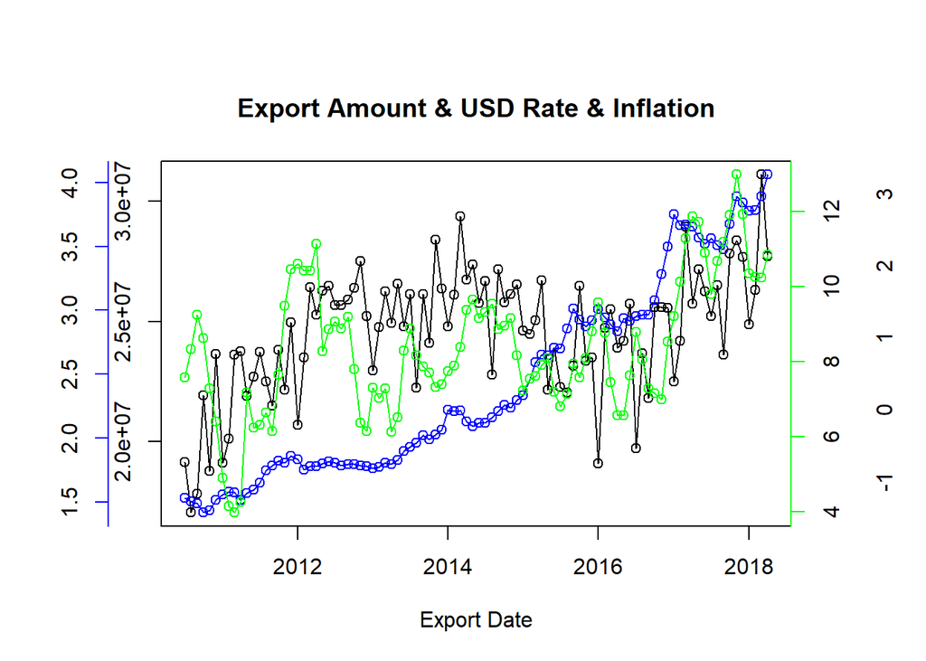

```r
# The side for the axes.  The next one will go on
# the left, the following two on the right side
sides <- list(2, 4, 4)

# The number of "lines" into the margin the axes will be
lines <- list(2, NA, 2)


for(i in 3:5) {
  par(new = TRUE)
  plot(exp_data_final$Export_Date, exp_data_final[[i]], axes = FALSE, col = colors[i - 1], xlab = "", ylab = "")
  axis(at = pretty(exp_data_final[[i]]), side = sides[[i-2]], line = lines[[i-2]],
       col = colors[i - 1])
  #mtext(2,text=colnames(exp_data_final)[i],line=2)
  lines(exp_data_final$Export_Date, exp_data_final[[i]], col = colors[i - 1])
}
```

## Trade Deficit Amount by Sub Sector Names

[figure not shown]

```r
   emp_by_sectors <- exp_data %>%
   filter(Main_Sector_Flag == 0) %>%
   group_by(Sector_Name_Eng,Sub_Sector_Type_Code) %>%
   summarize(Total_Export_Amount = sum(Export_Amount))

   imp_by_sectors <- imp_data %>%
   filter(Main_Sector_Flag == 0) %>%
   group_by(Sector_Name_Eng,Sub_Sector_Type_Code) %>%
   summarize(Total_Import_Amount = sum(Import_Amount))

 trade_deficit_sub_sector <- inner_join(imp_by_sectors, emp_by_sectors, by =c("Sub_Sector_Type_Code", "Sub_Sector_Type_Code")) %>%
   mutate(Trade_Deficit_Amount = Total_Import_Amount - Total_Export_Amount)%>%
   arrange(desc(Trade_Deficit_Amount))

trade_deficit_sub_sector %>%
  ggplot(aes(x=reorder(Sector_Name_Eng.x, Trade_Deficit_Amount),
             y=Trade_Deficit_Amount, color =Sector_Name_Eng.x, fill=Sector_Name_Eng.x)) +
  geom_bar(stat = "identity") +
  coord_flip() +
  labs(x = "Sub Sector Name", y = "Trade Deficit Amount") +
  ggtitle("Trade Deficit by Sub Sectors") +
  theme(legend.position = "none", axis.text.x = element_text(angle = 0, vjust = 10.0, hjust = 0.0, size = 1))
```

## Trade Deficit Amount by Sub Sectors Codes

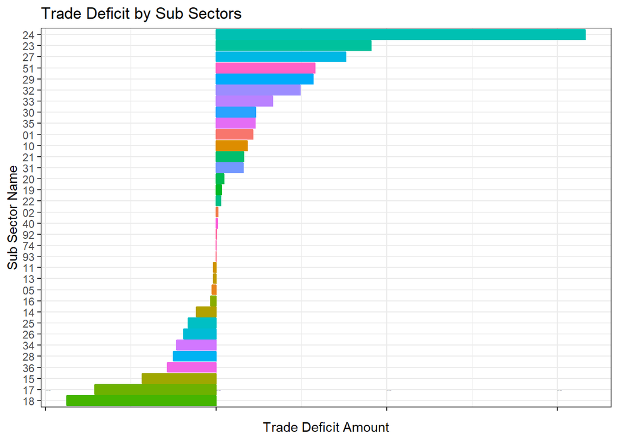

```r
   emp_by_sectors <- exp_data %>%
   filter(Main_Sector_Flag == 0) %>%
   group_by(Sector_Name_Eng,Sub_Sector_Type_Code) %>%
   summarize(Total_Export_Amount = sum(Export_Amount))

   imp_by_sectors <- imp_data %>%
   filter(Main_Sector_Flag == 0) %>%
   group_by(Sector_Name_Eng,Sub_Sector_Type_Code) %>%
   summarize(Total_Import_Amount = sum(Import_Amount))

 trade_deficit_sub_sector <- inner_join(imp_by_sectors, emp_by_sectors, by =c("Sub_Sector_Type_Code", "Sub_Sector_Type_Code")) %>%
   mutate(Trade_Deficit_Amount = Total_Import_Amount - Total_Export_Amount)%>%
   arrange(desc(Trade_Deficit_Amount))

trade_deficit_sub_sector %>%
  ggplot(aes(x=reorder(Sub_Sector_Type_Code, Trade_Deficit_Amount),
             y=Trade_Deficit_Amount, color =Sub_Sector_Type_Code, fill=Sub_Sector_Type_Code)) +
  geom_bar(stat = "identity") +
  coord_flip() +
  labs(x = "Sub Sector Name", y = "Trade Deficit Amount") +
  ggtitle("Trade Deficit by Sub Sectors") +
  theme(legend.position = "none", axis.text.x = element_text(angle = 0, vjust = 10.0, hjust = 0.0, size = 1))
```